# IDS investigation worksheet

#2.3 Grouping data with seasons now included

```r
season_holiday_comparison <- seoul_bikes %>%
  group_by(seasons, holiday) %>%
  summarise(
    avg_rentals = mean(rented_bike_count, na.rm = TRUE),
    .groups = "drop"
  )
```

#2.4 Grouped bar chart of seasonal data

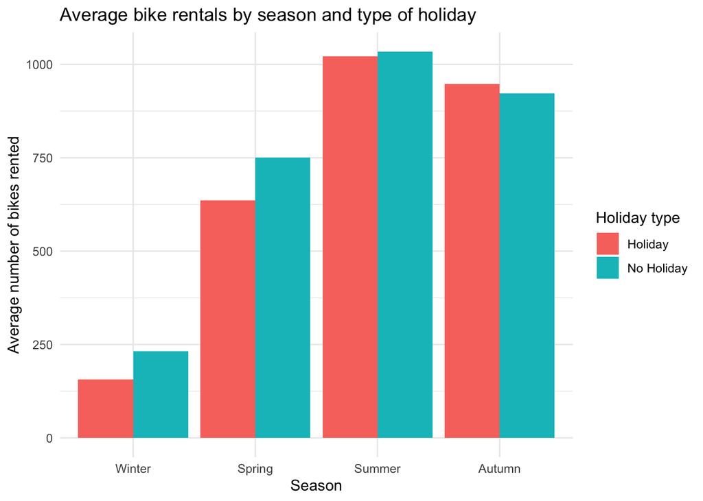

```r
ggplot(season_holiday_comparison,
       # Used factor() to display seasons in chronological order on x-axis instead of alphabetical
       aes(x = factor(seasons,
                      levels = c("Winter", "Spring",
                                 "Summer", "Autumn")),
           y = avg_rentals,
           fill = holiday)) +
  geom_col(position = "dodge") +
  labs(
    title = "Average bike rentals by season and type of holiday",
    x = "Season",
    y = "Average number of bikes rented",
    fill = "Holiday type"
  ) +
  theme_minimal()
```

Observations: This grouped bar chart shows how the average bike rentals varies between holidays and non-holidays across the four seasons. Summer has the highest average rentals, with roughly the same number in each category, whereas winter has the lowest. Autumn shows slighlty higher average rentals on holidays while summer shows minimal differences. Ocerall, the findings suggest that seasonal variation has stronger association with bike rental demand rather than holiday status (variation between holiday vs non holiday is small in each season whereas the average bike rentals is bigger) Seasons Holiday avg_rentals 1 Autumn Holiday 948. 2 Autumn No Holiday 923. 3 Spring Holiday 635. 4 Spring No Holiday 750. 5 Summer Holiday 1022. 6 Summer No Holiday 1034. 7 Winter Holiday 157. 8 Winter No Holiday 232.

Earlier analysis showed that non-holidays had 39.7% higher average rentals overall, the seasonal breakdown proves this relationship is not consitent throughout the year. Winter 47.8% higher Spring 18.1% higher Summer 1.2% higher Autmun -2.6% lower

Can temperature explain the seasonal differences in this demand?

#2.5 Grouping data by season, holiday and hour

```r
hourly_holiday_comparison <- seoul_bikes %>%
  group_by(seasons, holiday, hour) %>%
  summarise(
    avg_rentals = mean(rented_bike_count, na.rm = TRUE),
    .groups = "drop"
   )
```

From 2.1 all of the rest is very repeatable data - which is something important in R. #2.6 Data visualisation

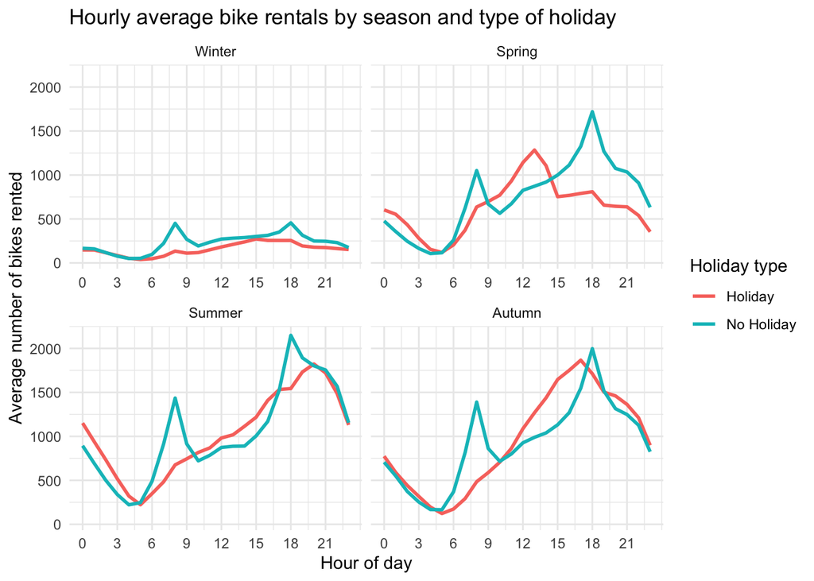

```r
ggplot(hourly_holiday_comparison,
       aes(x = hour, y = avg_rentals,
           colour = holiday)) +
  # Used geom_line() instead of geom_col() because I'm now investigating how rentals change throughout the day.
  geom_line(linewidth = 1) +
  # Used facet_wrap() for easier comparison
  facet_wrap(
    ~factor(seasons,
                      levels = c("Winter", "Spring",
                                 "Summer", "Autumn")),
    #added axes = "all_x" by asking GenAi because I wanted all graphs to have x-axis only the bottom 2 originally had it.
    axes = "all_x"
  )+
  scale_x_continuous(breaks = seq(0, 23, 3)) +

  labs(
    title = "Hourly average bike rentals by season and type of holiday",
    x = "Hour of day",
    y = "Average number of bikes rented",
    colour = "Holiday type"
  ) +
  theme_minimal()
```

Bimodals in the non-holiday lines. Holiday lines no clear comparisons. Morning peak around 8am on non-holidays Evening peak around 6pm Holiday rentals generally more evenly distributed

Next steps - write out cleaner observations Explore: Can temperature explain the seasonal differences in this demand? How does it link to the big question.

##Task 3

Identify if precipitation drops demand linearly or shows a sharp threshold

We look at rental counts at various levels of precipitation to see if demand decreases gradually as precipitation increases or drops off sharply above a certain point.

```r
library(tidyverse)
library(janitor)

# 3.1. Load the full Seoul Bike CSV.
bikes <- read_csv(
  "data/SeoulBikeData.csv",
  locale = locale(encoding = "latin1")
) %>%
  clean_names()
# 3.2 Keep only hours when the bike rental service was operating.
bikes <- bikes %>%
  filter(functioning_day == "Yes")
```

```r
# 3.3 Each row represents one hour. | means OR, and & means AND.
wet_hours <- bikes %>%
  filter(rainfall_mm > 0 | snowfall_cm > 0)

both_hours <- bikes %>%
  filter(rainfall_mm > 0 & snowfall_cm > 0)

wet_hours %>%
  summarise(hours = n())
```

```
## # A tibble: 1 × 1
##   hours
##   <int>
## 1   931
```

```r
both_hours %>%
  summarise(hours = n())
```

```
## # A tibble: 1 × 1
##   hours
##   <int>
## 1    28
```

931 hours had snow,rain or both 28hours had both rain and snow

```r
# 3.4 Compare rain and snow separately, keeping dry hours in both plots.
rain_data <- bikes %>%
  filter(snowfall_cm == 0)

snow_data <- bikes %>%
  filter(rainfall_mm == 0)
```

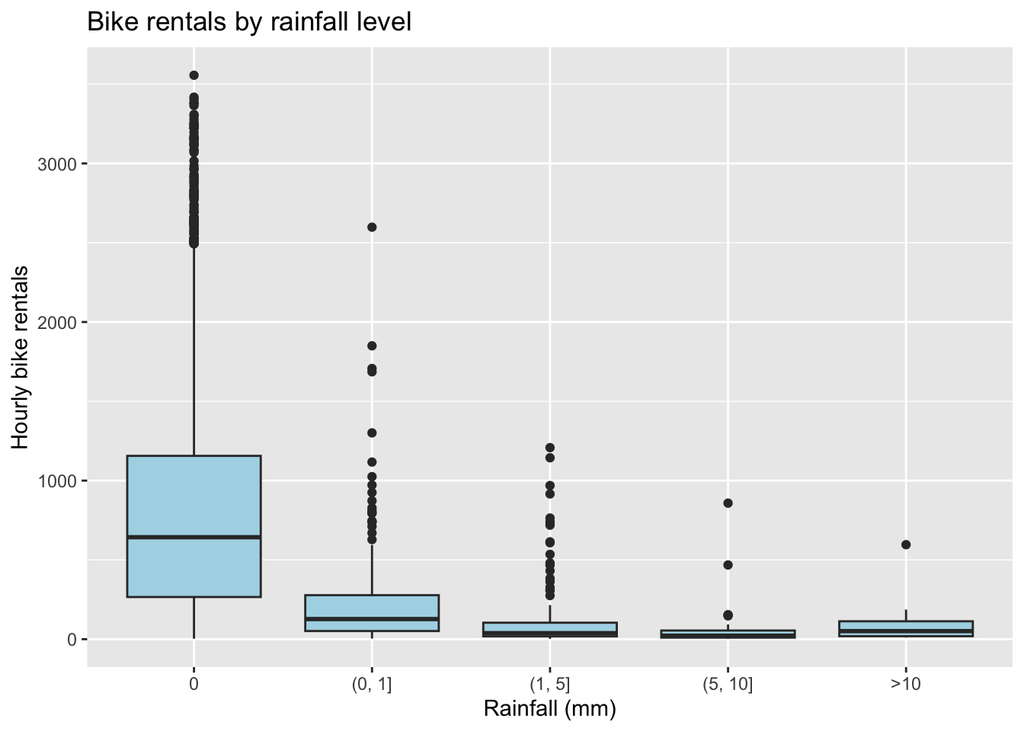

```r
# Define precipitation bands
rain_data <- rain_data %>%
  mutate(
    rain_level = case_when(
      rainfall_mm == 0 ~ "0",
      rainfall_mm > 0 & rainfall_mm <= 1 ~ "(0, 1]",
      rainfall_mm > 1 & rainfall_mm <= 5 ~ "(1, 5]",
      rainfall_mm > 5 & rainfall_mm <= 10 ~ "(5, 10]",
      rainfall_mm > 10 ~ ">10"
    ),
    rain_level = fct_relevel(
      rain_level,
      "0", "(0, 1]", "(1, 5]", "(5, 10]", ">10"
    )
  )

snow_data <- snow_data %>%
  mutate(
    snow_level = case_when(
      snowfall_cm == 0 ~ "0",
      snowfall_cm > 0 & snowfall_cm <= 1 ~ "(0, 1]",
      snowfall_cm > 1 & snowfall_cm <= 3 ~ "(1, 3]",
      snowfall_cm > 3 & snowfall_cm <= 5 ~ "(3, 5]",
      snowfall_cm > 5 ~ ">5"
    ),
    snow_level = fct_relevel(
      snow_level,
      "0", "(0, 1]", "(1, 3]", "(3, 5]", ">5"
    )
  )
# Rainfall box plot: exclude snow to isolate rainfall
ggplot(
  data = rain_data,
  mapping = aes(x = rain_level, y = rented_bike_count)
) +
  geom_boxplot(fill = "lightblue") +
  labs(
    title = "Bike rentals by rainfall level",
    x = "Rainfall (mm)",
    y = "Hourly bike rentals"
  )
```

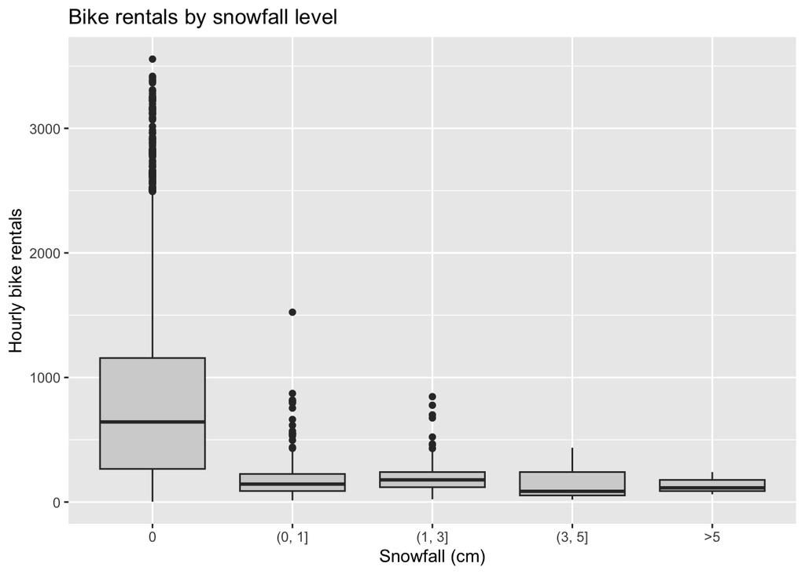

```r
# Snowfall box plot: exclude rain to isolate snowfall
ggplot(
  data = snow_data,
  mapping = aes(x = snow_level, y = rented_bike_count)
) +
  geom_boxplot(fill = "lightgrey") +
  labs(
    title = "Bike rentals by snowfall level",
    x = "Snowfall (cm)",
    y = "Hourly bike rentals"
  )
```

Both box plots show significantly lower median bike rentals during hours with precipitation. The largest drop is between zero precipitation and the lowest positive precipitation band, suggesting a possible threshold for the initiation of rain or snow. Demand for rainfall falls further at higher levels, while snowfall has a less consistent pattern. These results suggest a nonlinear relationship but the group plots cannot identify a specific threshold. Differences may also be due to other factors like temperature, season and time of day.

```r
# 3.6 Check the number of hours and the median rentals in each band.
rain_summary <- rain_data %>%
  group_by(rain_level) %>%
  summarise(
    hours = n(),
    median_rentals = median(rented_bike_count, na.rm = TRUE)
  )

snow_summary <- snow_data %>%
  group_by(snow_level) %>%
  summarise(
    hours = n(),
    median_rentals = median(rented_bike_count, na.rm = TRUE)
  )

rain_summary
```

```
## # A tibble: 5 × 3
##   rain_level hours median_rentals
##   <fct>      <int>          <dbl>
## 1 0           7534            643
## 2 (0, 1]       256            127
## 3 (1, 5]       169             38
## 4 (5, 10]       42             22
## 5 >10           21             51
```

```r
snow_summary
```

```
## # A tibble: 5 × 3
##   snow_level hours median_rentals
##   <fct>      <int>          <dbl>
## 1 0           7534            643
## 2 (0, 1]       240            144
## 3 (1, 3]       128            178
## 4 (3, 5]        44             86
## 5 >5             3            114
```

Median hourly bike rentals dropped from 643 at dry hours to 127 with rainfall above 0 and up to 1mm, which is a decrease of about 80%. The median then fell to 38 for raifall between 1 and 5mm and 22 between 5 and 10mm. It increased when above 10mm to 51, this band contained only 21 observations. The greatest decrease happened between dry conditions and light rain, meaning a possible threshold near the start of rain.

Snowfall showed a similar initial drop. Median rentals decreased from 643 with no precipitation to 144 with snowfall above 0 and up to 1 cm, a decrease of approximately 78%. The medians across higher snowfall bands were 178, 86 and 114, showing an inconsistent pattern. The highest snowfall band contained only three observations, making its median unclear.

To sum things up these results at first show a big reduction in percipitation rather than a slow and steady decline.We cannot establish a threshold using the data ## Task 4

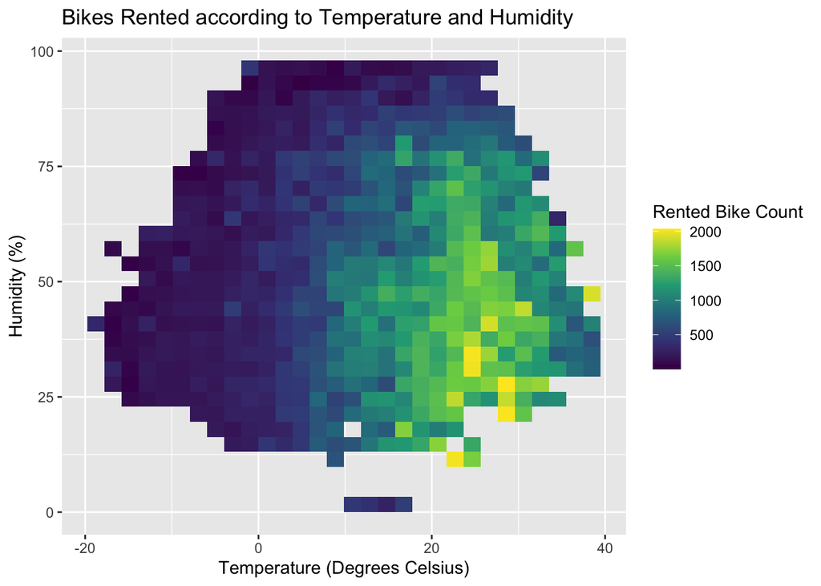

```r
seoul_bikes |> ggplot(aes(x = temperature_c, y = humidity_percent,
                          z = rented_bike_count
                      )) + stat_summary_2d(
                        fun = mean, aes(fill
                                        = after_stat(value))
                      ) + scale_fill_viridis_c() +
                          labs(x = "Temperature (Degrees Celsius)",
                               y = "Humidity (%)",
                               fill = "Rented Bike Count",
                               title = "Bikes Rented according to Temperature and Humidity")
```

Looking at the graph, we can see that bikes are rented most when temperature is between 20 and 25 degrees and humidity is relatively low. The sales drop off to often below 500 bikes rented per hour on average whenever temperature is below zero regardless of humidity, and there is a similar drop off when humidity nears 100% although to a less extreme extent. This implies that temperature is a greater concern when people are deciding whether or not to rent bikes, which makes intuitive sense as it is a more immediately noticeable factor.

##Task 5

#used genAI to help with creating variables to run code

```r
seoul_bikes <- seoul_bikes %>%
  mutate(
    day_type = if_else(
      lubridate::wday(as.Date(date, format = "%d/%m/%Y"),
                      week_start = 1) >= 6 | holiday == "Holiday",
      "Weekend/Holiday",
      "Weekday"
    )
  )
```

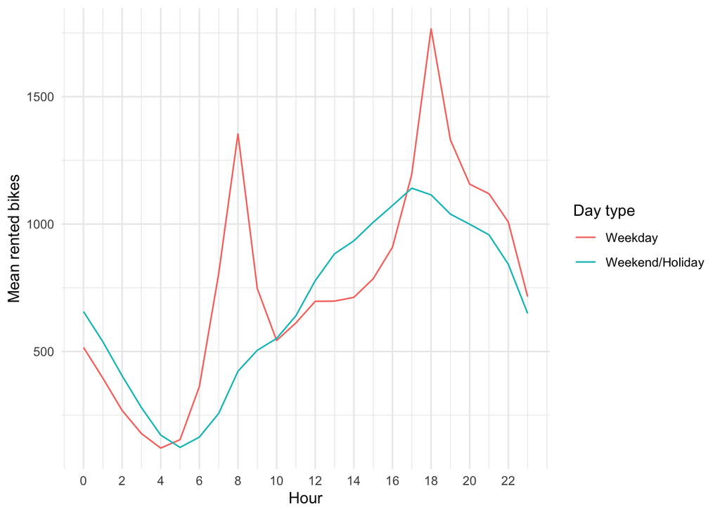

```r
hour_profile <- seoul_bikes |>
group_by(day_type, hour) |>
summarise(
mean_rented_bikes = mean(`rented_bike_count`,na.rm = TRUE),
.groups = "drop"
)

ggplot(hour_profile, aes(x = hour, y = mean_rented_bikes, colour = day_type)) +
geom_line() +
labs(x = "Hour", y = "Mean rented bikes", colour = "Day type"
) +
  scale_x_continuous(breaks = seq(0, 23, by = 2)) +
theme_minimal()
```

```r
hour_profile |>
group_by(day_type) |>
slice_max(mean_rented_bikes, n = 1)
```

```
## # A tibble: 2 × 3
## # Groups:   day_type [2]
##   day_type         hour mean_rented_bikes
##   <chr>           <dbl>             <dbl>
## 1 Weekday            18             1766.
## 2 Weekend/Holiday    17             1141.
```

## Splitting Data for Model Training

```r
#set.seed(123)
#bike_split <- initial_split(seoul_bikes, prop = 0.8)
#bike_train <- training(bike_split)
#bike_test <- testing(bike_split)
```

## Checking Correlations

```r
seoul_bikes <- seoul_bikes |>
  mutate(peak = ifelse(hour %in% c(7:9, 17:19), 1, 0))

seoul_bikes |>
  select(where(is.numeric)) |>
  cor() |>
  round(2)
```

```
##                         rented_bike_count  hour temperature_c humidity_percent
## rented_bike_count                    1.00  0.43          0.56            -0.20
## hour                                 0.43  1.00          0.12            -0.24
## temperature_c                        0.56  0.12          1.00             0.17
## humidity_percent                    -0.20 -0.24          0.17             1.00
## wind_speed_m_s                       0.13  0.29         -0.04            -0.34
## visibility_10m                       0.21  0.10          0.03            -0.55
## dew_point_temperature_c              0.40  0.00          0.91             0.54
## solar_radiation_mj_m2                0.27  0.14          0.35            -0.46
## rainfall_mm                         -0.13  0.01          0.05             0.24
## snowfall_cm                         -0.15 -0.02         -0.22             0.11
## peak                                 0.29  0.12          0.00             0.00
##                         wind_speed_m_s visibility_10m dew_point_temperature_c
## rented_bike_count                 0.13           0.21                    0.40
## hour                              0.29           0.10                    0.00
## temperature_c                    -0.04           0.03                    0.91
## humidity_percent                 -0.34          -0.55                    0.54
## wind_speed_m_s                    1.00           0.18                   -0.18
## visibility_10m                    0.18           1.00                   -0.18
## dew_point_temperature_c          -0.18          -0.18                    1.00
## solar_radiation_mj_m2             0.33           0.15                    0.10
## rainfall_mm                      -0.02          -0.17                    0.13
## snowfall_cm                       0.00          -0.12                   -0.15
## peak                              0.03           0.00                    0.00
##                         solar_radiation_mj_m2 rainfall_mm snowfall_cm  peak
## rented_bike_count                        0.27       -0.13       -0.15  0.29
## hour                                     0.14        0.01       -0.02  0.12
## temperature_c                            0.35        0.05       -0.22  0.00
## humidity_percent                        -0.46        0.24        0.11  0.00
## wind_speed_m_s                           0.33       -0.02        0.00  0.03
## visibility_10m                           0.15       -0.17       -0.12  0.00
## dew_point_temperature_c                  0.10        0.13       -0.15  0.00
## solar_radiation_mj_m2                    1.00       -0.07       -0.07 -0.10
## rainfall_mm                             -0.07        1.00        0.01  0.02
## snowfall_cm                             -0.07        0.01        1.00  0.00
## peak                                    -0.10        0.02        0.00  1.00
```

```r
seoul_bikes |>
  mutate(
    precipitation = ifelse(rainfall_mm > 0 | snowfall_cm > 0, 1, 0)
  ) |>
  group_by(precipitation) |>
  count()
```

```
## # A tibble: 2 × 2
## # Groups:   precipitation [2]
##   precipitation     n
##           <dbl> <int>
## 1             0  7534
## 2             1   931
```

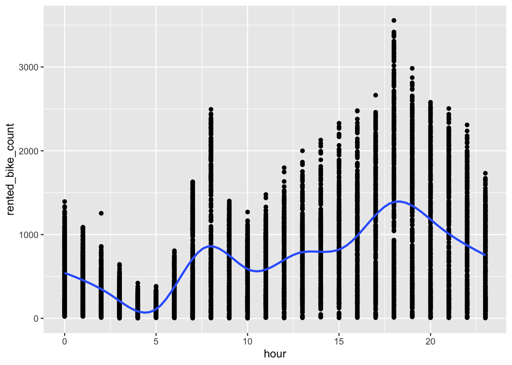

```r
seoul_bikes |>
  ggplot(aes(hour, rented_bike_count)) +
  geom_point() +
  geom_smooth(se = FALSE)
```

```r
  #although can consider peak and non-peak hours, the afternoon hours overall suggest that demand still remains high, so it would be wrong to group the afternoon hours with other times. As such, it might be worth dropping the peak variable.
```

### Variables to Drop

To simplify the model, we might want to group variables together into new ones, such as for rainfall_mm and snowfall_cm, we may be able to mutate these into a new variable called precipitation. Perhaps we can model this as just a binary variable, as in many days within the data there was neither.

```r
#We merge rainfall and snowfall variables together, and consider weekdays & weekends, and also join hour and holiday together as their behaviours are different based on whether it is a holiday or not.
#seoul_bikes <- seoul_bikes |>
#  mutate(
#    precipitation = ifelse(rainfall_mm > 0 | snowfall_cm > 0, 1, 0),
#    is_weekend   = wday(dmy(date)) %in% c(1, 7),
#    hour_holiday = interaction(hour, holiday, sep = "_")
#  ) |>
#  select(
#    rented_bike_count,
#    hour_holiday,
#    is_weekend,
#    temperature_c,
#    humidity_percent,
#    precipitation
#    seasons,
#  )

#seoul_bikes
```

## Initial Plots

```r
seoul_bikes |>  ggplot(data = _, mapping = aes(x = temperature_c, y = rented_bike_count)) +
  geom_point(mapping = aes(color = holiday, alpha = visibility_10m, shape = seasons)) +
  geom_smooth(se = FALSE) +
  facet_wrap( ~ holiday) +
  labs(x = "Temperature",
       y = "Rent Bike Count",
       title = "How Temperatures Affects the Quantity of Bikes Rented",
       colour = "Holiday",
       shape = "Season",
       alpha = "Visibility (10m)"
      )
#will need scaling later to make sure points are more visible

seoul_bikes |>  ggplot(data = _, mapping = aes(x = temperature_c, y = rented_bike_count)) +
  geom_bin_2d()

seoul_bikes |> ggplot(data = _, mapping = aes(x = rented_bike_count, fill = seasons)) +
  geom_density(mapping = aes(alpha = 0.5)) +
  facet_wrap(~ holiday, scales = "free") +
  scale_y_continuous(labels = scales::comma)

seoul_bikes |> ggplot(data = _, mapping = aes(x = rented_bike_count, fill = seasons)) +
  geom_histogram(bins = 30) +
  facet_grid(seasons ~ holiday, scales = "free")

seoul_bikes |> ggplot(data = _, mapping = aes(x = seasons, y = rented_bike_count)) +
  geom_boxplot()

seoul_bikes |> ggplot(mapping = aes(x = rented_bike_count, fill = holiday, alpha = 0.1)) +
  geom_density()

seoul_bikes |> ggplot(mapping = aes(x = hour, y = rented_bike_count)) +
  geom_col() +
  facet_grid(seasons ~ holiday, scales = "free") +
  scale_y_continuous(labels = scales::comma)

seoul_bikes |> mutate(
  snow = ifelse(snowfall_cm == 0, FALSE, TRUE)
) |>
  ggplot(mapping = aes(x = rented_bike_count, color = snow, alpha = 0.1)) +
  geom_density() +
  scale_y_continuous(labels = scales::comma)

seoul_bikes <- seoul_bikes %>%
  mutate(
    wind_group = cut(
      wind_speed_m_s,
      breaks = c(-Inf, 1, 2, 3, 4, Inf),
      labels = c("0-1", "1-2", "2-3", "3-4", "4+")
    )
  )

ggplot(seoul_bikes,
       aes(x = wind_group,
           y = rented_bike_count)) +
  stat_summary(
    fun = mean,
    geom = "col",
    fill = "steelblue"
  ) +
  labs(
    title = "Average Bike Rentals at Different Wind Speeds",
    x = "Wind Speed (m/s)",
    y = "Average Number of Bikes Rented"
  ) +
  theme_minimal()
```

[output not shown]

```r
seoul_bikes
```

[output not shown]

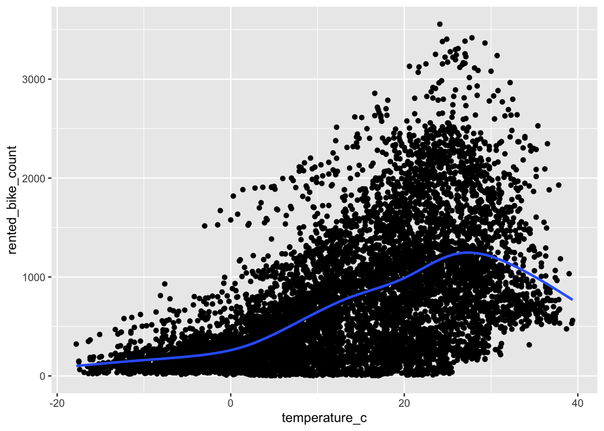

```r
scatter_plot <- function(df, x, y){
  df |>
      ggplot(aes({{ x }}, {{ y }})) +
      geom_point() +
      geom_smooth(se = FALSE)
}

bar_plot <- function(df, x, y){
  df |>
    ggplot(aes({{ x }}, {{ y }})) +
    geom_col()
}

#scatter_plot(seoul_bikes, hour, rented_bike_count)
scatter_plot(seoul_bikes, temperature_c, rented_bike_count)
```

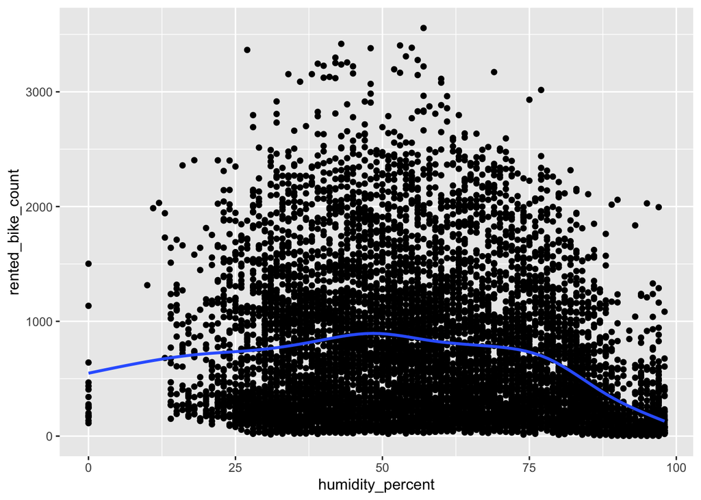

```r
scatter_plot(seoul_bikes, humidity_percent, rented_bike_count)
```

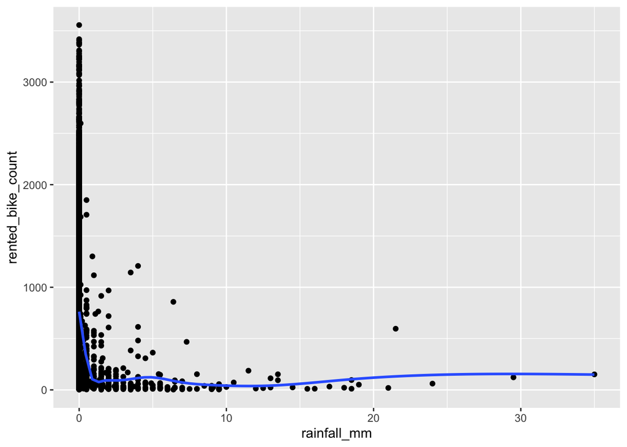

```r
scatter_plot(seoul_bikes, rainfall_mm, rented_bike_count)
```

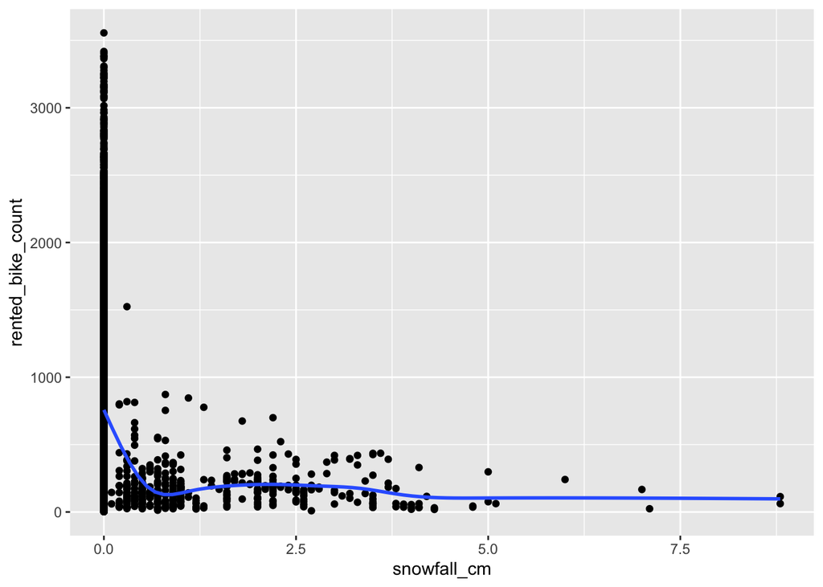

```r
scatter_plot(seoul_bikes, snowfall_cm, rented_bike_count)
```

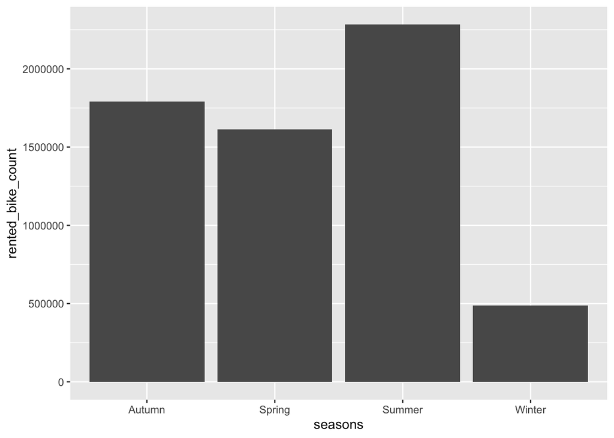

```r
bar_plot(seoul_bikes, seasons, rented_bike_count)
```

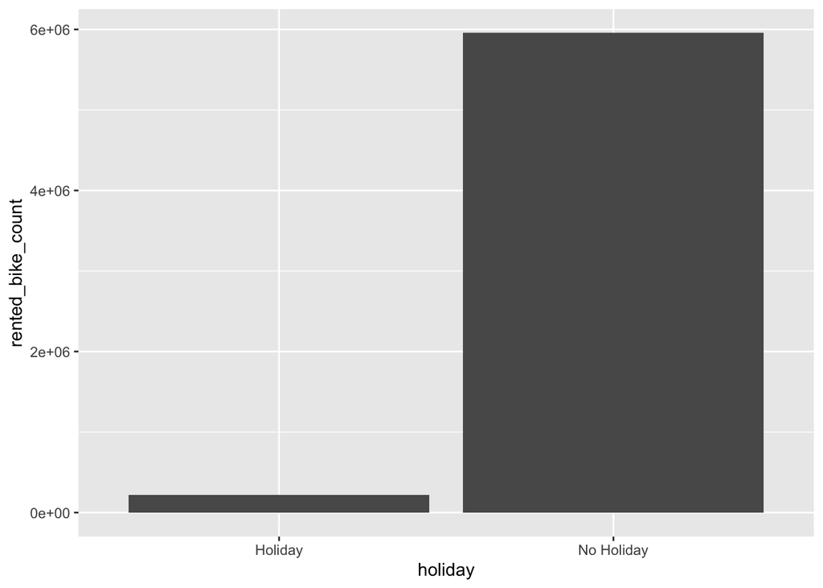

```r
bar_plot(seoul_bikes, holiday, rented_bike_count)
```

```r
seoul_bikes_clean <- seoul_bikes |>
    mutate(
    precipitation = ifelse(rainfall_mm > 0 | snowfall_cm > 0, 1, 0),
    is_weekend   = wday(dmy(date)) %in% c(1, 7),
  ) |>
  select(
    rented_bike_count,
    hour,
    holiday,
    is_weekend,
    temperature_c,
    humidity_percent,
    precipitation,
    seasons,
  )
```